# Lab 4 — Certificar la tierra y migrar

PROCEDE en los ejidos de México (réplica de de Janvry et al., 2015)

Autor/a

Economía del Desarrollo (06230) · Universidad ICESI

Fecha de publicación

1 de octubre de 2026

## 1 De qué se trata

Hasta 1992, la tierra de los **ejidos** mexicanos —las comunidades agrarias creadas por la reforma agraria de 1914–1992— no se podía vender ni arrendar, y el derecho a la parcela se mantenía de una sola forma: **trabajándola**, uno mismo y su familia. La Constitución ordenaba quitarle la parcela a quien no la cultivara **dos años seguidos** y dársela a otro beneficiario. El derecho dependía de estar.

En 1992 una reforma constitucional cambió eso, y entre 1993 y 2006 el programa **PROCEDE** recorrió los ejidos midiendo parcelas y entregando **certificados** a cada ejidatario. Con el certificado el derecho ya no dependía de usar la tierra: se podía arrendar o vender a otros ejidatarios, y uno se podía ir sin perderla.

La pregunta de de Janvry, Emerick, Gonzalez-Navarro y Sadoulet es directa:

> **Si la tierra ya no exige que uno se quede, ¿la gente se va?**

Es el canal de Besley y Ghatak (2010) que llamamos «dejar de vigilar con el cuerpo»: cuando los derechos son inseguros, la gente gasta su propio tiempo en protegerlos. Un certificado libera ese tiempo.

**AdvertenciaAcá no hay sorteo: hay calendario**

PROCEDE llegó a casi todos los ejidos, pero **en años distintos**. La identificación sale de comparar a los que se certificaron **antes** con los que todavía no: una **diferencia en diferencias con adopción escalonada**.

Funciona bajo un supuesto que no se puede probar: que, sin PROCEDE, la migración habría evolucionado **igual** en los ejidos tempranos y en los tardíos (**tendencias paralelas**). Si PROCEDE llegó primero adonde la migración ya venía subiendo, el método confunde esa tendencia con un efecto. Sección 7 y Sección 8 ponen el supuesto a prueba, y Sección 9 busca la misma respuesta en otras dos bases.

## 2 Preparación

```r
if (!require("pacman")) install.packages("pacman")
pacman::p_load(tidyverse, scales, fixest, broom, did)

hogares     <- read_rds("datos/janvry_hogares.rds")            # Tabla 1 y A4
localidades <- read_rds("datos/janvry_localidades.rds")        # Tabla 2, cols. 1-5
placebo     <- read_rds("datos/janvry_localidades_80_90.rds")  # Tabla 2, col. 6
censo       <- read_rds("datos/janvry_censo_ejidal.rds")       # Tabla 3
procampo    <- read_rds("datos/janvry_procampo.rds")           # Figura 2
satelite    <- read_rds("datos/janvry_satelite.rds")           # Tabla 4 y Figura 1

# El azul del control y el naranja del tratamiento son los mismos de los Labs 2 y 3.
azul    <- "#2c7fb8"
naranja <- "#d95f0e"
colores_cohorte <- c("Certificado en 1997" = "#d95f0e",
                     "Certificado en 1998" = "#fdae61",
                     "Certificado en 1999" = "#a6bddb",
                     "Aún sin certificar en 2000" = "#2c7fb8")

# Saca el coeficiente de una variable de un modelo como una fila de tibble.
fila <- function(modelo, variable, columna) {
  tidy(modelo) |>
    filter(term == variable) |>
    transmute(columna, coef = estimate, ee = std.error, p = p.value,
              n = nobs(modelo))
}

# Para escribir números en el texto con coma decimal.
num <- function(x, d = 4) formatC(x, format = "f", digits = d, decimal.mark = ",")
```

Seis archivos, uno por cada base del paper. El corazón del lab es **hogares**: el panel de hogares de PROGRESA, 1997–2000, cruzado con el año en que su ejido terminó PROCEDE. Las otras cinco sirven para ver si la misma historia aparece con otra unidad, otra fuente y otro período. Ver el codebook.

## 3 Una mirada a los datos

```r
dim(hogares)
```

```
[1] 27189    21
```

```r
hogares |>
  summarise(hogares = n_distinct(hogar), ejidos = n_distinct(ejido),
            estados = n_distinct(estado), anios = n_distinct(anio))
```

| hogares | ejidos | estados | anios |
| --- | --- | --- | --- |
| 7577 | 127 | 7 | 4 |

Es un **panel**: los mismos hogares observados cuatro años seguidos, en ejidos de siete estados pobres (Guerrero, Hidalgo, Michoacán, Puebla, Querétaro, San Luis Potosí y Veracruz). El paper habla de 195 ejidos empatados con PROGRESA; la muestra de la Tabla 1 se queda solo con los que se certificaron **después de 1996**, porque los que ya estaban certificados en 1997 no tienen ningún «antes» que aportar.

```r
hogares |>
  group_by(anio) |>
  summarise(hogares = n(), tasa_migrante = mean(migrante))
```

| anio | hogares | tasa_migrante |
| --- | --- | --- |
| 1997 | 6954 | 0.0221455 |
| 1998 | 6954 | 0.0464481 |
| 1999 | 6715 | 0.0652271 |
| 2000 | 6566 | 0.0808712 |

El resultado es `migrante`: **1 si el hogar ya tiene un migrante permanente**. Ojo con la palabra «ya»: la variable es **acumulada**, vale 1 si alguien se fue ese año o cualquier año anterior de la muestra. Por eso solo puede subir, y sube en todos lados. Lo que importa no es que suba, sino **dónde sube más**.

```r
hogares |>
  count(anio_procede, anio, certificado) |>
  pivot_wider(names_from = anio, values_from = n)
```

| anio_procede | certificado | 1997 | 1998 | 1999 | 2000 |
| --- | --- | --- | --- | --- | --- |
| 1997 | 0 | 858 | NA | NA | NA |
| 1997 | 1 | NA | 858 | 894 | 855 |
| 1998 | 0 | 982 | 982 | NA | NA |
| 1998 | 1 | NA | NA | 961 | 913 |
| 1999 | 0 | 912 | 912 | 917 | NA |
| 1999 | 1 | NA | NA | NA | 895 |
| 2000 | 0 | 1378 | 1378 | 1266 | 1332 |
| 2002 | 0 | 664 | 664 | 601 | 604 |
| 2003 | 0 | 429 | 429 | 417 | 400 |
| 2004 | 0 | 634 | 634 | 606 | 547 |
| 2005 | 0 | 1043 | 1043 | 998 | 967 |
| 2006 | 0 | 54 | 54 | 55 | 53 |

El tratamiento, `certificado`, no es otra cosa que comparar el año de la encuesta con el año en que el ejido terminó PROCEDE. Un ejido que terminó en 1997 cuenta como certificado **desde el inicio de 1998**. Los que terminaron en 2000 o después nunca aparecen tratados en el panel.

## 4 El calendario de PROCEDE

```r
calendario <- satelite |>
  distinct(ejido, anio_procede) |>
  count(anio_procede, name = "ejidos")

hasta_1997 <- with(calendario, sum(ejidos[anio_procede <= 1997]) / sum(ejidos))
```

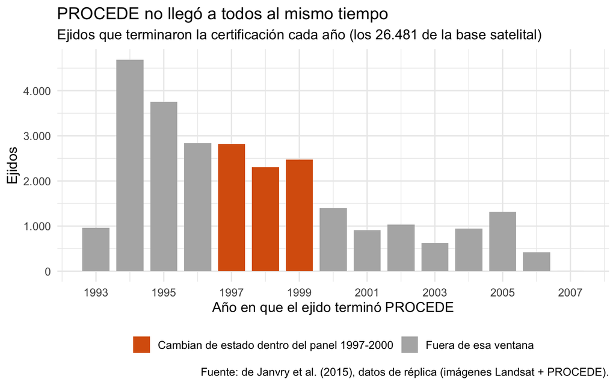

Figura 1: Ejidos que terminaron PROCEDE cada año. En naranja, los que cambian de estado dentro del panel PROGRESA.

```r
g1 <- calendario |>
  mutate(ventana = if_else(anio_procede %in% 1997:1999,
                           "Cambian de estado dentro del panel 1997-2000",
                           "Fuera de esa ventana")) |>
  ggplot(aes(anio_procede, ejidos, fill = ventana)) +
  geom_col(width = 0.8) +
  scale_fill_manual(values = c("Cambian de estado dentro del panel 1997-2000" = naranja,
                               "Fuera de esa ventana" = "grey70")) +
  scale_x_continuous(breaks = seq(1993, 2007, by = 2)) +
  scale_y_continuous(labels = label_number(big.mark = ".", decimal.mark = ",")) +
  labs(title = "PROCEDE no llegó a todos al mismo tiempo",
       subtitle = "Ejidos que terminaron la certificación cada año (los 26.481 de la base satelital)",
       x = "Año en que el ejido terminó PROCEDE", y = "Ejidos", fill = NULL,
       caption = "Fuente: de Janvry et al. (2015), datos de réplica (imágenes Landsat + PROCEDE).") +
  theme_minimal(base_size = 13) +
  theme(legend.position = "bottom")
g1
```

El programa fue rapidísimo: el 57 % de los ejidos ya había terminado en 1997. Pero dejó una cola larga hasta 2006, y esa es la variación que usa el paper: en cualquier año hay ejidos certificados y ejidos que todavía esperan.

Dentro del panel, los ejidos se parten en **cohortes** según el primer año en que aparecen certificados:

```r
hogares <- hogares |>
  mutate(
    primer_anio_cert = if_else(anio_procede <= 1999, anio_procede + 1, 0),
    cohorte = case_when(
      anio_procede == 1997 ~ "Certificado en 1997",
      anio_procede == 1998 ~ "Certificado en 1998",
      anio_procede == 1999 ~ "Certificado en 1999",
      TRUE                 ~ "Aún sin certificar en 2000"
    ),
    cohorte = factor(cohorte, levels = names(colores_cohorte))
  )

hogares |>
  distinct(ejido, cohorte) |>
  count(cohorte, name = "ejidos")
```

| cohorte | ejidos |
| --- | --- |
| Certificado en 1997 | 16 |
| Certificado en 1998 | 17 |
| Certificado en 1999 | 18 |
| Aún sin certificar en 2000 | 76 |

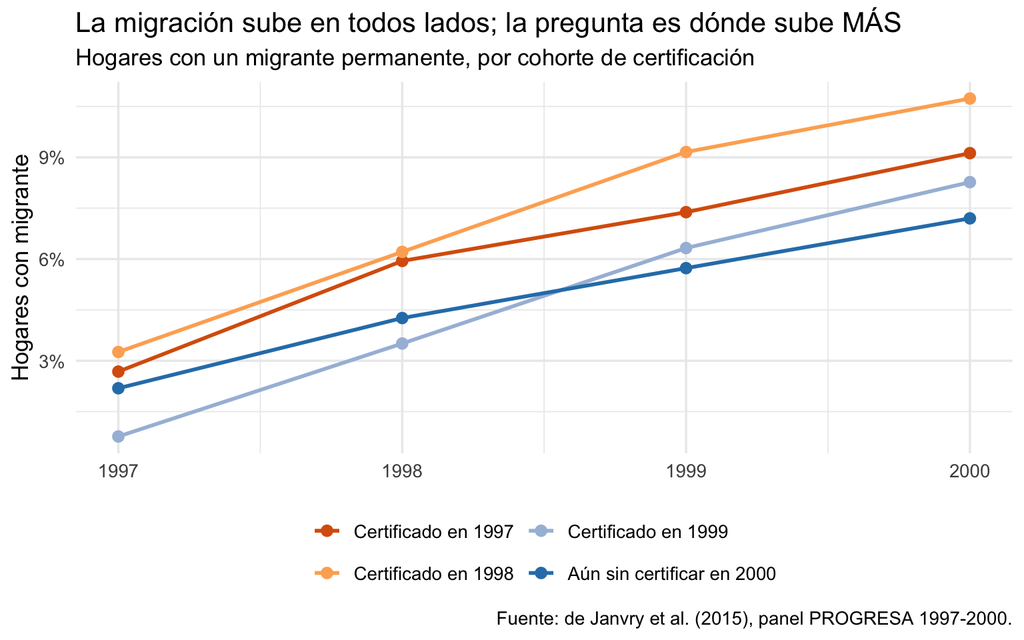

Figura 2: Hogares con un migrante permanente, por cohorte de certificación.

```r
tendencias <- hogares |>
  group_by(cohorte, anio) |>
  summarise(tasa_migrante = mean(migrante), .groups = "drop")

g2 <- ggplot(tendencias, aes(anio, tasa_migrante, color = cohorte)) +
  geom_line(linewidth = 1) +
  geom_point(size = 2.5) +
  scale_color_manual(values = colores_cohorte) +
  scale_y_continuous(labels = label_percent(accuracy = 1)) +
  labs(title = "La migración sube en todos lados; la pregunta es dónde sube MÁS",
       subtitle = "Hogares con un migrante permanente, por cohorte de certificación",
       x = NULL, y = "Hogares con migrante", color = NULL,
       caption = "Fuente: de Janvry et al. (2015), panel PROGRESA 1997-2000.") +
  guides(color = guide_legend(nrow = 2)) +
  theme_minimal(base_size = 13) +
  theme(legend.position = "bottom")
g2
```

**TipCómo se lee esta gráfica**

El **nivel** de cada línea no dice nada: los ejidos difieren en mil cosas fijas —lejanía, tamaño, tradición migratoria— y el efecto fijo de ejido se las va a llevar todas. Lo que importa es la **pendiente**: ¿se empina la línea de una cohorte justo después de certificarse, más de lo que se empinan las de quienes todavía no se certifican?

## 5 El resultado titular

### 5.1 Antes de la regresión: un 2×2 hecho a mano

La cohorte certificada en 1998 cambia de estado entre 1998 y 1999. Los que siguen sin certificar en 2000 no cambian. La diferencia en diferencias más simple posible:

```r
dd <- hogares |>
  filter(anio %in% c(1998, 1999),
         cohorte %in% c("Certificado en 1998", "Aún sin certificar en 2000")) |>
  group_by(cohorte, anio) |>
  summarise(tasa = mean(migrante), .groups = "drop") |>
  pivot_wider(names_from = anio, values_from = tasa, names_prefix = "a") |>
  mutate(cambio = a1999 - a1998)

dd
```

| cohorte | a1998 | a1999 | cambio |
| --- | --- | --- | --- |
| Certificado en 1998 | 0.0621181 | 0.0915713 | 0.0294532 |
| Aún sin certificar en 2000 | 0.0425988 | 0.0573168 | 0.0147180 |

```r
did_2x2 <- diff(rev(dd$cambio))
```

La cohorte tratada subió 0,0295; el control, 0,0147. La resta de las restas da **0,0147**. El segundo «menos» es el que hace el trabajo: se lleva todo lo que le pasó a todos en 1999 —una crisis, una sequía, el dólar— y deja solo lo que le pasó de más a quien se certificó.

### 5.2 La regresión de efectos fijos

La ecuación (1) del paper generaliza esa resta a todas las cohortes y todos los años:

$$y_{ijt} = \delta\,\text{Certif}_{jt} + \gamma_j + \alpha_t + \varepsilon_{ijt}$$

con $\gamma_j$ un efecto fijo de **ejido** (todo lo fijo del ejido) y $\alpha_t$ un efecto fijo de **año** (todo lo que le pasa a todos en $t$). Los errores estándar se agrupan por ejido, porque el tratamiento se asigna a nivel de ejido.

```r
m_titular <- feols(migrante ~ certificado | ejido + anio,
                   data = hogares, cluster = ~ejido)
summary(m_titular)
```

```
OLS estimation, Dep. Var.: migrante
Observations: 27,189
Fixed-effects: ejido: 127,  anio: 4
Standard-errors: Clustered (ejido)
            Estimate Std. Error t value Pr(>|t|)
certificado 0.014895   0.006123 2.43242 0.016403 *
---
Signif. codes:  0 '***' 0.001 '**' 0.01 '*' 0.05 '.' 0.1 ' ' 1
RMSE: 0.219067     Adj. R2: 0.042375
                 Within R2: 2.829e-4
```

```r
media_dep <- mean(hogares$migrante)
efecto_relativo <- coef(m_titular)[["certificado"]] / media_dep
```

**El paper reporta 0,0149 (EE 0,0061) con 27.189 observaciones** (Tabla 1, col. 1). La réplica da **0,0149** (EE 0,0061) con 27.189 observaciones: el mismo número.

Tener el certificado sube 1,5 **puntos** la probabilidad de que el hogar tenga un migrante. Suena a poco, pero sobre una media de 5,3 % es un aumento de **28 %**. Esa es la cifra del resumen del paper.

## 6 ¿Aguanta? Las otras cinco columnas de la Tabla 1

Cada columna ataca una amenaza distinta. Lea la pregunta antes que el número.

```r
# (2) ¿Cambiaron los hogares, o NAFTA cambió los precios agrícolas?
m2 <- feols(migrante ~ certificado + propietario + hombres_17a30 + jefa_mujer +
              edad_jefe + valor_agricola | ejido + anio,
            data = hogares, cluster = ~ejido)

# (3) ¿Y si el efecto fijo de ejido no basta? Uno por HOGAR.
#     fixef.rm = "none" deja los hogares observados un solo año, como Stata.
m3 <- feols(migrante ~ certificado | hogar + anio,
            data = hogares, cluster = ~ejido, fixef.rm = "none")

# (4) ¿Y si cada estado tuvo su propia evolución? Año x estado.
m4 <- feols(migrante ~ certificado | ejido + estado^anio,
            data = hogares, cluster = ~ejido)

# (5) ¿Y si los hogares con más jóvenes migraban más con el tiempo de todos modos?
m5 <- feols(migrante ~ certificado + propietario + hombres_17a30 + jefa_mujer + edad_jefe +
              i(anio, propietario, 1997) + i(anio, hombres_17a30, 1997) +
              i(anio, jefa_mujer, 1997) + i(anio, edad_jefe, 1997) | ejido + anio,
            data = hogares, cluster = ~ejido)

# (6) ¿Y si PROCEDE llegó antes a ejidos que iban a migrar más de todos modos?
m6 <- feols(migrante ~ certificado +
              i(anio, ejidatarios, 1997) + i(anio, area_total, 1997) +
              i(anio, no_votantes, 1997) + i(anio, latitud, 1997) +
              i(anio, longitud, 1997) + i(anio, dist_ciudad_km, 1997) +
              i(anio, prop_parcelada, 1997) + i(anio, marginacion, 1997) | ejido + anio,
            data = hogares, cluster = ~ejido)

tabla1 <- bind_rows(
  fila(m_titular, "certificado", "(1) Efectos fijos de ejido y año"),
  fila(m2, "certificado", "(2) + controles de hogar y valor agrícola"),
  fila(m3, "certificado", "(3) Efectos fijos de hogar"),
  fila(m4, "certificado", "(4) Año x estado"),
  fila(m5, "certificado", "(5) Características del hogar x año"),
  fila(m6, "certificado", "(6) Características del ejido x año")
)
tabla1 |> mutate(across(c(coef, ee, p), \(x) round(x, 4)))
```

| columna | coef | ee | p | n |
| --- | --- | --- | --- | --- |
| (1) Efectos fijos de ejido y año | 0.0149 | 0.0061 | 0.0164 | 27189 |
| (2) + controles de hogar y valor agrícola | 0.0147 | 0.0065 | 0.0268 | 23421 |
| (3) Efectos fijos de hogar | 0.0153 | 0.0062 | 0.0143 | 27189 |
| (4) Año x estado | 0.0172 | 0.0058 | 0.0039 | 27189 |
| (5) Características del hogar x año | 0.0157 | 0.0063 | 0.0143 | 24533 |
| (6) Características del ejido x año | 0.0130 | 0.0062 | 0.0367 | 27189 |

| Columna | Publicado | N publicado |
| --- | --- | --- |
| (1) | 0,0149 (0,0061) | 27.189 |
| (2) | 0,0147 (0,0066) | 23.421 |
| (3) | 0,0153 (0,0062) | 27.189 |
| (4) | 0,0172 (0,0059) | 27.189 |
| (5) | 0,0157 (0,0063) | 24.533 |
| (6) | 0,0130 (0,0062) | 27.189 |

Los coeficientes y las N coinciden. Algún error estándar difiere en el cuarto decimal porque Stata y `fixest` no cuentan igual los grados de libertad cuando hay efectos fijos (volvemos sobre esto en Sección 7, donde sí importa).

La columna 6 es la más importante. PROCEDE terminó antes en ejidos **más cerca de las ciudades**, por ejemplo. El efecto fijo ya se lleva la distancia, pero no que los ejidos cercanos a las ciudades hayan migrado cada vez más en esos años **por estar cerca de las ciudades**. Interactuar las características del ejido con el año controla justo eso, y el coeficiente apenas se mueve.

**ImportanteLo que esta tabla NO prueba**

Las seis columnas son la **misma comparación** con más cosas a la derecha. Si hay algo que **no se observa** y que cambió justo cuando llegó PROCEDE, ninguna columna lo ve. Que el coeficiente sea estable es buena señal, no una prueba.

## 7 ¿Tendencias paralelas?

El supuesto no se puede probar, pero sí se puede **atacar por su lado visible**: antes de certificarse, ¿los ejidos tempranos y los tardíos se movían igual?

### 7.1 La Tabla A4 del apéndice

Se colapsa a nivel de ejido × año y se miran **solo los años antes de certificarse**. Si el año de PROCEDE predice los cambios de migración *antes* del programa, el calendario no es inocente.

```r
ejido_anio <- hogares |>
  group_by(ejido, anio_procede, anio) |>
  summarise(migrante = mean(migrante), .groups = "drop") |>
  arrange(ejido, anio) |>
  group_by(ejido) |>
  # El cambio contra el año anterior, solo si el año anterior existe (como l. en Stata)
  mutate(cambio = if_else(lag(anio) == anio - 1, migrante - lag(migrante), NA_real_)) |>
  ungroup() |>
  mutate(py99 = anio_procede == 1999, py00 = anio_procede == 2000,
         py01 = anio_procede > 2000)

pre <- ejido_anio |> filter(!is.na(cambio), anio <= anio_procede)

a4_1 <- feols(cambio ~ py99 + py00 + py01, data = filter(pre, anio == 1998), vcov = "hetero")
a4_2 <- feols(cambio ~ py00 + py01 | anio, cluster = ~ejido,
              data = filter(pre, anio <= 1999, anio_procede >= 1999))
a4_3 <- feols(cambio ~ py01 | anio, cluster = ~ejido,
              data = filter(pre, anio <= 2000, anio_procede >= 2000))

etable(a4_1, a4_2, a4_3, digits = 4)
```

|  | a4_1 | a4_2 | a4_3 |
| --- | --- | --- | --- |
| Dependent Var.: | cambio | cambio | cambio |
| Constant | 0.0302*** (0.0086) |  |  |
| py99TRUE | -0.0011 (0.0113) |  |  |
| py00TRUE | -0.0040 (0.0110) | -0.0087 (0.0092) |  |
| py01TRUE | -0.0131 (0.0090) | -0.0102 (0.0086) | 0.0015 (0.0046) |
| Fixed-Effects: | —————— | —————- | ————— |
| anio | No | Yes | Yes |
| _______________ | __________________ | ________________ | _______________ |
| S.E. type | Heteroskedas.-rob. | by: ejido | by: ejido |
| Observations | 111 | 187 | 225 |
| R2 | 0.04699 | 0.01929 | 0.00233 |
| Within R2 | – | 0.01704 | 0.00039 |

```r
p_pre_1 <- wald(a4_1, keep = "py", print = FALSE)$p
p_pre_2 <- wald(a4_2, keep = "py", print = FALSE)$p
```

Las pruebas conjuntas dan p = 0,190 y p = 0,493 (el apéndice publica 0,190 y 0,493). No se rechaza que el año de PROCEDE sea irrelevante para la migración **antes** del programa.

La columna 4 busca otra cosa: una **caída justo antes** de certificarse (el *Ashenfelter dip*). Si los hogares se quedaron a cuidar la parcela mientras PROCEDE medía linderos, el «efecto» podría ser solo la vuelta a lo normal.

```r
a4_4 <- feols(migrante ~ anio_de + anio_antes + dos_antes | anio + ejido,
              data = ejido_anio |>
                filter(anio <= anio_procede) |>
                mutate(anio_de    = as.numeric(anio == anio_procede),
                       anio_antes = as.numeric(anio == anio_procede - 1),
                       dos_antes  = as.numeric(anio == anio_procede - 2)),
              fixef.rm = "none",
              vcov = vcov_cluster(~ejido, ssc = ssc(fixef.K = "full")))
summary(a4_4)
```

```
OLS estimation, Dep. Var.: migrante
Observations: 406
Fixed-effects: anio: 4,  ejido: 127
Standard-errors: Clustered (ejido)
            Estimate Std. Error   t value Pr(>|t|)
anio_de     0.001798   0.015049  0.119482  0.90508
anio_antes -0.002146   0.010701 -0.200542  0.84138
dos_antes  -0.001463   0.008945 -0.163592  0.87031
---
Signif. codes:  0 '***' 0.001 '**' 0.01 '*' 0.05 '.' 0.1 ' ' 1
RMSE: 0.025267     Adj. R2: 0.664792
                 Within R2: 0.001733
```

Publicado: 0,0018 (0,0150), −0,0021 (0,0107) y −0,0015 (0,0089), N = 406. Igual.

**NotaUna trampa de réplica: los grados de libertad**

Fíjese en la línea `ssc(fixef.K = "full")`. Stata, al correr `reg` con dummies de ejido, cuenta los 127 efectos fijos como parámetros cuando corrige los errores estándar por muestra pequeña; `fixest`, por defecto, no. Con 27.189 observaciones eso no cambia nada (es el cuarto decimal de Sección 6). Con **406 observaciones y 127 efectos fijos**, sí: sin esa línea los coeficientes salen idénticos pero los EE salen alrededor de 20 % **más chicos**, y por eso demasiado optimistas. Ninguno de los dos programas avisa.

**Lo que el Escéptico debe decir.** «No rechazar» no es «probar». Los EE de la columna 4 son del mismo tamaño que el efecto que estamos buscando (0,015). Con 127 ejidos, una pre-tendencia de ese tamaño pasaría sin ser detectada.

### 7.2 El estudio de evento

En vez de **un** coeficiente, uno por cada año relativo a la certificación. Los de antes de 0 son la prueba visual de tendencias paralelas; los de después muestran cómo se acumula el efecto. Usamos `sunab()` (Sun y Abraham, 2021), que compara cada cohorte solo contra quienes no están tratados; Sección 8 explica por qué eso importa.

```r
hogares <- hogares |>
  mutate(cohorte_sa = if_else(primer_anio_cert == 0, 10000, primer_anio_cert))

m_evento <- feols(migrante ~ sunab(cohorte_sa, anio) | ejido + anio,
                  data = hogares, cluster = ~ejido)

evento <- tidy(m_evento) |>
  mutate(t = as.integer(str_extract(term, "-?\\d+$"))) |>
  select(t, coef = estimate, ee = std.error) |>
  bind_rows(tibble(t = -1L, coef = 0, ee = 0)) |>
  arrange(t)
evento |> mutate(across(c(coef, ee), \(x) round(x, 4)))
```

| t | coef | ee |
| --- | --- | --- |
| -3 | -0.0223 | 0.0191 |
| -2 | -0.0121 | 0.0080 |
| -1 | 0.0000 | 0.0000 |
| 0 | 0.0103 | 0.0051 |
| 1 | 0.0157 | 0.0089 |
| 2 | 0.0191 | 0.0151 |

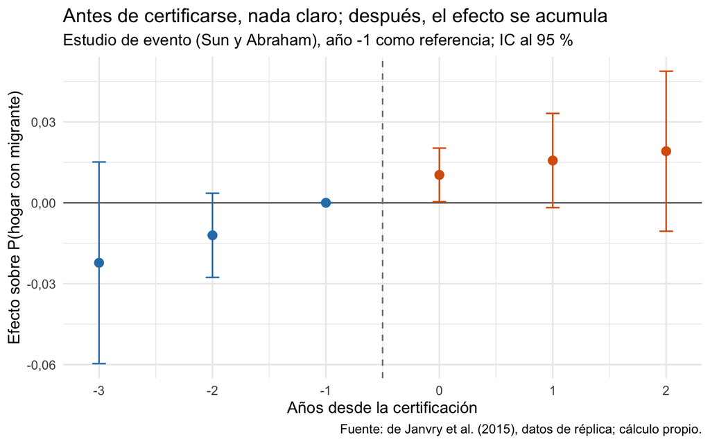

Figura 3: Estudio de evento (Sun y Abraham). Año −1 como referencia; intervalos al 95 %.

```r
g3 <- ggplot(evento, aes(t, coef)) +
  geom_hline(yintercept = 0, color = "grey40") +
  geom_vline(xintercept = -0.5, linetype = "dashed", color = "grey50") +
  geom_errorbar(aes(ymin = coef - 1.96 * ee, ymax = coef + 1.96 * ee),
                width = 0.12, color = ifelse(evento$t < 0, azul, naranja)) +
  geom_point(size = 3, color = ifelse(evento$t < 0, azul, naranja)) +
  scale_x_continuous(breaks = -3:2) +
  scale_y_continuous(labels = label_number(decimal.mark = ",")) +
  labs(title = "Antes de certificarse, nada claro; después, el efecto se acumula",
       subtitle = "Estudio de evento (Sun y Abraham), año -1 como referencia; IC al 95 %",
       x = "Años desde la certificación", y = "Efecto sobre P(hogar con migrante)",
       caption = "Fuente: de Janvry et al. (2015), datos de réplica; cálculo propio.") +
  theme_minimal(base_size = 13)
g3
```

Después de certificarse, el efecto crece año a año, como debe crecer en una variable acumulada. Antes, los puntos son **negativos** aunque no significativos: si algo, los ejidos tratados migraban un poco **menos** que el año previo a certificarse. El año −3 solo existe para una cohorte y el −2 para dos, por eso sus intervalos son tan anchos. ¿Es eso una tendencia que ya venía subiendo? Los datos no alcanzan para decidirlo, y esa es una buena pregunta para el Escéptico.

## 8 El problema del TWFE con adopción escalonada

La regresión de Sección 5 se llama TWFE (*two-way fixed effects*). Por dentro promedia **muchas comparaciones 2×2**, y no todas son limpias. Cuando la cohorte de 1999 se certifica, el TWFE usa como «control» a la cohorte de 1998, **que ya estaba tratada**. Si el efecto **crece con el tiempo** —y acá crece—, esa comparación resta parte del efecto y sesga el promedio. Es la crítica de Goodman-Bacon (2021) y de Callaway y Sant’Anna (2021), posterior al paper.

La solución de Callaway y Sant’Anna: estimar un efecto por cada cohorte $g$ y cada año $t$, el $ATT(g,t)$, usando como control **solo a quienes todavía no están tratados**, y después promediar.

```r
set.seed(2026)   # los intervalos simultáneos salen de un bootstrap
cs <- att_gt(yname = "migrante", tname = "anio", idname = "hogar",
             gname = "primer_anio_cert", data = as.data.frame(hogares),
             panel = TRUE, allow_unbalanced_panel = TRUE,
             control_group = "notyettreated", clustervars = "ejido",
             est_method = "reg", base_period = "universal")

cs_simple   <- aggte(cs, type = "simple")
cs_dinamico <- aggte(cs, type = "dynamic")

tidy(cs) |>
  select(cohorte = group, anio = time, att = estimate, ee = std.error) |>
  mutate(across(c(att, ee), \(x) round(x, 4)))
```

| cohorte | anio | att | ee |
| --- | --- | --- | --- |
| 1998 | 1997 | 0.0000 | NA |
| 1998 | 1998 | 0.0095 | 0.0103 |
| 1998 | 1999 | 0.0079 | 0.0135 |
| 1998 | 2000 | 0.0143 | 0.0142 |
| 1999 | 1997 | -0.0076 | 0.0096 |
| 1999 | 1998 | 0.0000 | NA |
| 1999 | 1999 | 0.0123 | 0.0079 |
| 1999 | 2000 | 0.0158 | 0.0120 |
| 2000 | 1997 | -0.0202 | 0.0215 |
| 2000 | 1998 | -0.0134 | 0.0154 |
| 2000 | 1999 | 0.0000 | NA |
| 2000 | 2000 | 0.0048 | 0.0096 |

```r
sa_att <- summary(m_evento, agg = "ATT")$coeftable["ATT", ]

comparacion <- tibble(
  estimador = c("TWFE (paper, Tabla 1 col. 1)",
                "Sun y Abraham (promedio post)",
                "Callaway y Sant'Anna (no aún tratados)"),
  att = c(coef(m_titular)[["certificado"]], sa_att[["Estimate"]], cs_simple$overall.att),
  ee  = c(se(m_titular)[["certificado"]], sa_att[["Std. Error"]], cs_simple$overall.se)
)
comparacion |> mutate(across(c(att, ee), \(x) round(x, 4)))
```

| estimador | att | ee |
| --- | --- | --- |
| TWFE (paper, Tabla 1 col. 1) | 0.0149 | 0.0061 |
| Sun y Abraham (promedio post) | 0.0135 | 0.0068 |
| Callaway y Sant’Anna (no aún tratados) | 0.0108 | 0.0068 |

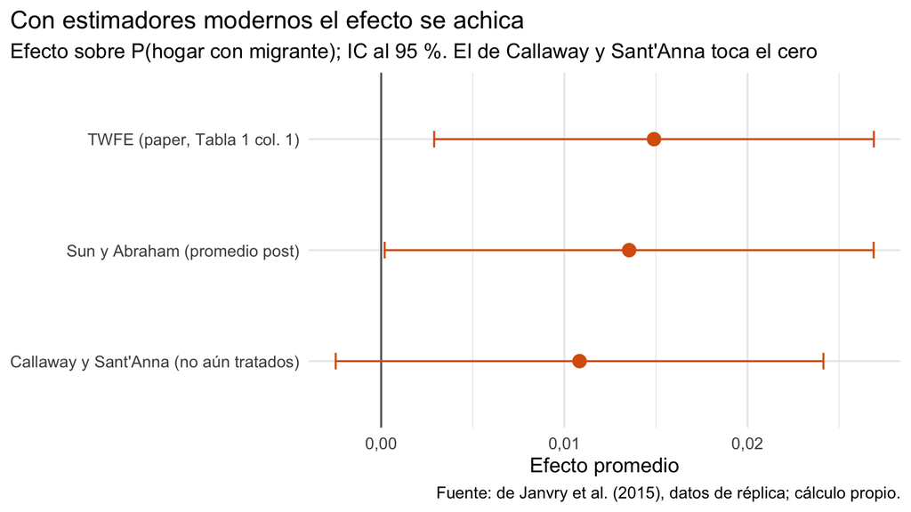

Figura 4: Tres estimadores del mismo efecto, con intervalos al 95 %.

```r
g4 <- comparacion |>
  mutate(estimador = fct_rev(fct_inorder(estimador))) |>
  ggplot(aes(att, estimador)) +
  geom_vline(xintercept = 0, color = "grey40") +
  geom_errorbar(aes(xmin = att - 1.96 * ee, xmax = att + 1.96 * ee),
                width = 0.15, orientation = "y", color = naranja) +
  geom_point(size = 3.5, color = naranja) +
  scale_x_continuous(labels = label_number(decimal.mark = ",")) +
  labs(title = "Con estimadores modernos el efecto se achica",
       subtitle = "Efecto sobre P(hogar con migrante); IC al 95 %. El de Callaway y Sant'Anna toca el cero",
       x = "Efecto promedio", y = NULL,
       caption = "Fuente: de Janvry et al. (2015), datos de réplica; cálculo propio.") +
  theme_minimal(base_size = 13) +
  theme(plot.title.position = "plot")
g4
```

**ImportanteLectura honesta**

El **signo y el orden de magnitud sobreviven**: los tres estimadores dicen que certificar aumentó la migración en algo más de un punto. Pero el punto baja de 0,0149 a 0,0108 con Callaway y Sant’Anna, y su intervalo (-0,0025 a 0,0241) incluye el cero. Con 127 ejidos y un solo año antes del tratamiento para la primera cohorte, los datos de hogares no dan para mucho más.

Esta no es una crítica a los autores: el estimador no existía cuando escribieron. Pero es la razón por la que importa que el paper **no descanse en una sola base**.

## 9 Otras dos bases, el mismo signo

### 9.1 Población de las localidades: censos 1990 y 2000 (Tabla 2)

Otra unidad (la localidad), otra fuente (el censo), otro período y **todo el país**, no solo localidades pobres. Solo dos fotos: 1990 (antes) y 2000 (después). La comparación es entre localidades de ejidos certificados en 1993–1999 y las de ejidos certificados después. La regla de muestra del paper (nota 14) deja solo las localidades con más de 20 habitantes en 1990, porque las muy pequeñas desaparecen o se reagrupan.

```r
loc <- localidades |>
  filter(pob_1990 > 20) |>
  mutate(
    despues = as.numeric(anio == 2000),
    cert_93_99 = as.numeric(anio_procede >= 1993 & anio_procede <= 1999),
    cert_x_2000 = cert_93_99 * despues,
    anios_cert  = if_else(anio_procede < 2000, 2000 - anio_procede, 0),
    cert_x_2000_x_anios = cert_x_2000 * anios_cert,
    temprano_x_2000 = as.numeric(anio_procede <= 1996) * despues,
    tardio_x_2000   = as.numeric(anio_procede %in% 1997:1999) * despues
  )

t2_1 <- feols(poblacion ~ despues + cert_x_2000 | ejido, loc, cluster = ~ejido)
t2_2 <- feols(log_pob ~ despues + cert_x_2000 | ejido, loc, cluster = ~ejido)
t2_3 <- feols(log_pob ~ despues + cert_x_2000 + valor_agricola | ejido, loc, cluster = ~ejido)
t2_4 <- feols(log_pob ~ despues + cert_x_2000 + cert_x_2000_x_anios | ejido, loc, cluster = ~ejido)
t2_5 <- feols(log_pob ~ despues + temprano_x_2000 + tardio_x_2000 | ejido, loc, cluster = ~ejido)

# Col. 6, el PLACEBO: la misma comparación una década antes, cuando PROCEDE no existía.
t2_6 <- feols(log_pob ~ I(anio == 1990) + cert_93_99_x_1990 | ejido,
              data = filter(placebo, pob_1980 > 20), cluster = ~ejido)

etable(t2_1, t2_2, t2_3, t2_4, t2_5, t2_6, digits = 4, fitstat = ~n)
```

|  | t2_1 | t2_2 | t2_3 | t2_4 | t2_5 | t2_6 |
| --- | --- | --- | --- | --- | --- | --- |
| Dependent Var.: | poblacion | log_pob | log_pob | log_pob | log_pob | log_pob |
| despues | -9.631*** (1.001) | -0.2069*** (0.0105) | -0.1986*** (0.0184) | -0.2069*** (0.0105) | -0.2069*** (0.0105) |  |
| cert_x_2000 | -3.689** (1.148) | -0.0404** (0.0128) | -0.0341* (0.0167) | -0.0206 (0.0195) |  |  |
| valor_agricola |  |  | 0.0036 (0.0077) |  |  |  |
| cert_x_2000_x_anios |  |  |  | -0.0054 (0.0039) |  |  |
| temprano_x_2000 |  |  |  |  | -0.0592*** (0.0144) |  |
| tardio_x_2000 |  |  |  |  | -0.0196 (0.0151) |  |
| I(anio == 1990) |  |  |  |  |  | -0.2094*** (0.0125) |
| cert_93_99_x_1990 |  |  |  |  |  | -0.0082 (0.0148) |
| Fixed-Effects: | —————– | ——————- | ——————- | ——————- | ——————- | ——————- |
| ejido | Yes | Yes | Yes | Yes | Yes | Yes |
| ___________________ | _________________ | ___________________ | ___________________ | ___________________ | ___________________ | ___________________ |
| S.E.: Clustered | by: ejido | by: ejido | by: ejido | by: ejido | by: ejido | by: ejido |
| Observations | 34,656 | 34,656 | 24,170 | 34,656 | 34,656 | 24,910 |

**NotaOtra trampa de réplica: `%in%` y los faltantes**

Para construir `cert_93_99` usamos `anio_procede >= 1993 & anio_procede <= 1999` y no `anio_procede %in% 1993:1999`, que parece lo mismo. No lo es: `%in%` le da `FALSE` a una localidad **sin** año de PROCEDE y la mete como control; la comparación le da `NA` y la saca de la muestra, que es lo que hace Stata. Con `%in%` la columna 2 da −0,0401 en vez de −0,0404. No hay error, no hay advertencia: simplemente la tabla deja de ser la del paper.

Toda la Tabla 2 replica exacta: −3,6893 (1,1485) personas, −0,0404 (0,0128) en logaritmos, −0,0592 (0,0144) para los certificados antes de 1997 y −0,0196 (0,0151) para los de 1997–1999, con 34.656 observaciones (17.328 localidades).

```r
V <- vcov(t2_5)
dif <- coef(t2_5)[["temprano_x_2000"]] - coef(t2_5)[["tardio_x_2000"]]
ee_dif <- sqrt(V["temprano_x_2000", "temprano_x_2000"] + V["tardio_x_2000", "tardio_x_2000"] -
                 2 * V["temprano_x_2000", "tardio_x_2000"])
p_dif <- 2 * pt(-abs(dif / ee_dif), df = degrees_freedom(t2_5, "t"))
```

Las localidades de ejidos certificados perdieron un 4,0 % más de población, y la pérdida es mayor donde el certificado llevaba más años: temprano contra tardío difieren en -0,0397 (p = 0,007). El **placebo** de 1980–1990 da -0,0082 (EE 0,0148): antes de PROCEDE, las dos poblaciones evolucionaban igual. Esta es, de hecho, la prueba de tendencias paralelas **más convincente** del paper: tiene una década entera de «antes».

### 9.2 El censo ejidal 2007 (Tabla 3)

La tercera base es la más débil: es un **corte transversal**. En 2007 todos los ejidos ya estaban certificados, así que solo se puede comparar **cuántos años** llevaba cada uno.

```r
t3_1 <- feols(jovenes_migran ~ anios_certificado | estado, censo, cluster = ~municipio)
t3_2 <- feols(jovenes_migran ~ anios_certificado + semilla_mejorada + tractor +
                electricidad + log_dist_pa | estado, censo, cluster = ~municipio)
etable(t3_1, t3_2, digits = 4, fitstat = ~n)
```

|  | t3_1 | t3_2 |
| --- | --- | --- |
| Dependent Var.: | jovenes_migran | jovenes_migran |
| anios_certificado | 0.0035** (0.0013) | 0.0039** (0.0013) |
| semilla_mejorada |  | -0.0178. (0.0100) |
| tractor |  | -0.0048 (0.0105) |
| electricidad |  | 0.0384*** (0.0108) |
| log_dist_pa |  | 0.0528*** (0.0113) |
| Fixed-Effects: | —————– | —————— |
| estado | Yes | Yes |
| _________________ | _________________ | __________________ |
| S.E.: Clustered | by: municipio | by: municipio |
| Observations | 19,670 | 19,600 |

Publicado: 0,0035 (0,0013) y 0,0039 (0,0013), con 19.670 y 19.600 ejidos. Igual. Cada año más con certificado sube cerca de 0,4 puntos la probabilidad de que la mayoría de los jóvenes se vaya. Sin efecto fijo de ejido, esta regresión vale lo que valga el supuesto de que los ejidos tempranos y tardíos eran iguales en todo lo demás. Sirve como **coherencia**, no como prueba independiente.

## 10 ¿Y la tierra? Migración sin abandono

Si la gente se va, ¿la tierra queda baldía? Ese es el temor clásico contra liberalizar los mercados de tierra. El paper dice que no: los que se quedan cultivan la tierra de los que se fueron.

### 10.1 PROCAMPO, 1995 contra 2012 (Figura 2)

PROCAMPO es el programa de pagos por hectárea creado para compensar a los agricultores por el TLCAN. Sus registros dicen, ejido por ejido, cuántos productores cobraron y por cuánta área. Se compara el cambio 1995–2012 según el año en que el ejido se certificó, contra los certificados en 2005 o después.

```r
procampo <- procampo |>
  mutate(d_productores = log_productores_2012 - log_productores_1995,
         d_area        = log_area_2012 - log_area_1995,
         d_area_x_prod = (log_area_2012 - log_productores_2012) -
                         (log_area_1995 - log_productores_1995),
         anio_cert     = pmin(anio_procede, 2005))

m_fig2 <- feols(c(d_productores, d_area, d_area_x_prod) ~ i(anio_cert, ref = 2005) | estado,
                data = procampo, cluster = ~municipio)

fig2 <- map_dfr(1:3, function(k) {
  tidy(m_fig2[[k]]) |>
    mutate(panel = c("Cambio en log de productores", "Cambio en log del área",
                     "Cambio en log del área por productor")[k],
           anio = as.integer(str_extract(term, "\\d{4}")))
}) |>
  mutate(panel = fct_inorder(panel))
```

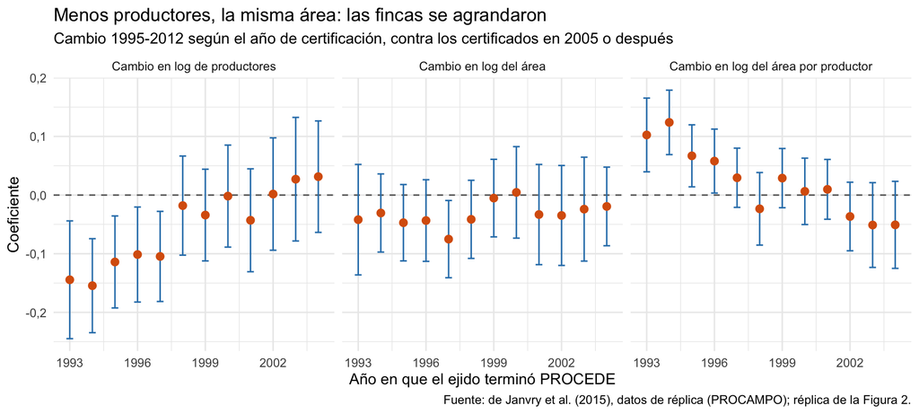

Figura 5: Réplica de la Figura 2 del paper. Referencia: ejidos certificados en 2005 o después; intervalos al 95 %.

```r
g5 <- ggplot(fig2, aes(anio, estimate)) +
  geom_hline(yintercept = 0, linetype = "dashed", color = "grey40") +
  geom_errorbar(aes(ymin = estimate - 1.96 * std.error, ymax = estimate + 1.96 * std.error),
                width = 0.3, color = azul) +
  geom_point(size = 2.5, color = naranja) +
  facet_wrap(~ panel) +
  scale_x_continuous(breaks = c(1993, 1996, 1999, 2002)) +
  scale_y_continuous(labels = label_number(decimal.mark = ",")) +
  labs(title = "Menos productores, la misma área: las fincas se agrandaron",
       subtitle = "Cambio 1995-2012 según el año de certificación, contra los certificados en 2005 o después",
       x = "Año en que el ejido terminó PROCEDE", y = "Coeficiente",
       caption = "Fuente: de Janvry et al. (2015), datos de réplica (PROCAMPO); réplica de la Figura 2.") +
  theme_minimal(base_size = 12)
g5
```

Los ejidos certificados primero (1993–1997) perdieron entre 10 y 15 % de sus productores, pero **no** perdieron área cultivada. Resultado: el área por productor subió, por ejemplo, 12 % en los certificados en 1994. Es la **consolidación** que predice la teoría cuando se abre el mercado de tierras.

### 10.2 Imágenes satelitales, 1993–2002–2007 (Tabla 4)

```r
t4 <- feols(log_area_agricola ~ certificado | ejido + anio,
            data = satelite, cluster = ~ejido, fixef.rm = "none")
summary(t4)
```

```
OLS estimation, Dep. Var.: log_area_agricola
Observations: 63,392
Fixed-effects: ejido: 22,007,  anio: 3
Standard-errors: Clustered (ejido)
            Estimate Std. Error  t value Pr(>|t|)
certificado 0.001257    0.00933 0.134716  0.89284
---
Signif. codes:  0 '***' 0.001 '**' 0.01 '*' 0.05 '.' 0.1 ' ' 1
RMSE: 0.39724     Adj. R2: 0.900916
                Within R2: 2.871e-7
```

Publicado: 0,0013 (0,0093), N = 63.392. Un **cero bien medido**: certificar no cambió el área cultivada del ejido.

## 11 Guardar las gráficas y los números titulares

```r
dir.create("figuras", showWarnings = FALSE)
ggsave("figuras/1-calendario-procede.png",        g1, width = 8,  height = 5,   dpi = 150)
ggsave("figuras/2-tendencias-por-cohorte.png",    g2, width = 8,  height = 5,   dpi = 150)
ggsave("figuras/3-estudio-de-evento.png",         g3, width = 8,  height = 5,   dpi = 150)
ggsave("figuras/4-twfe-vs-callaway-santanna.png", g4, width = 8,  height = 4.5, dpi = 150)
ggsave("figuras/5-consolidacion-procampo.png",    g5, width = 10, height = 4.5, dpi = 150)

jsonlite::write_json(list(
  certif_coef       = round(coef(m_titular)[["certificado"]], 4),
  certif_se         = round(se(m_titular)[["certificado"]], 4),
  n_obs             = nobs(m_titular),
  n_hogares         = n_distinct(hogares$hogar),
  n_ejidos          = n_distinct(hogares$ejido),
  media_dep         = round(media_dep, 4),
  efecto_relativo   = round(efecto_relativo, 3),
  certif_coef_col6  = round(coef(m6)[["certificado"]], 4),
  p_pretendencias   = round(p_pre_1, 3),
  sunab_att         = round(comparacion$att[2], 4),
  sunab_att_se      = round(comparacion$ee[2], 4),
  cs_att            = round(cs_simple$overall.att, 4),
  cs_att_se         = round(cs_simple$overall.se, 4),
  pob_log_coef      = round(coef(t2_2)[["cert_x_2000"]], 4),
  pob_log_se        = round(se(t2_2)[["cert_x_2000"]], 4),
  pob_placebo_coef  = round(coef(t2_6)[["cert_93_99_x_1990"]], 4),
  n_localidades     = nobs(t2_2) / 2,
  jovenes_coef      = round(coef(t3_1)[["anios_certificado"]], 4),
  area_agricola_coef = round(coef(t4)[["certificado"]], 4),
  area_x_prod_1994  = round(coef(m_fig2[[3]])[["anio_cert::1994"]], 3)
), "results.json", auto_unbox = TRUE, pretty = TRUE)
```

## 12 Síntesis y discusión

- Certificar la tierra subió 1,5 puntos (28 %) la probabilidad de que un hogar ejidal tuviera un migrante permanente (Sección 5). El resultado aguanta controles, efectos fijos de hogar y tendencias por estado y por características del ejido (Sección 6).
- Otra base, otra unidad, otro período: las localidades de ejidos certificados perdieron 4,0 % más de población, más cuanto antes se certificaron, y el placebo 1980–1990 da cero (Sección 9).
- La tierra **no se abandonó**: menos productores, la misma área, fincas más grandes (Sección 10). Migración y consolidación son dos caras del mismo mercado que se abre.
- Con los estimadores modernos de DiD escalonado, el efecto en hogares se achica y pierde precisión (Sección 8). El signo sobrevive; la precisión de la Tabla 1, no del todo. La fuerza del paper está en que **tres bases independientes** apuntan para el mismo lado.

**NotaPara discutir en clase**

1. ¿Por qué deberíamos creer que esto es causal si no hubo sorteo? Compare lo que hubo que defender acá con lo que compró el sorteo en el Lab 3 y la frontera en el Lab 2.
2. **Para el Escéptico.** ¿Qué determinó el orden en que PROCEDE llegó a los ejidos? Si llegó primero a los más organizados o mejor conectados, ¿no son esos también los que tienen redes de migración que maduran justo en esos años? ¿Qué prueba de Sección 7 o de Sección 9 responde mejor a eso, y cuál no lo responde?
3. En Sección 8, el efecto pasa de 0,015 a cerca de 0,011 y su intervalo toca el cero. ¿Cambia eso la conclusión del paper? ¿Cuál de las tres bases le parece ahora la evidencia más fuerte, y por qué?
4. Besley y Ghatak (2010) describen varios canales por los que los derechos de propiedad afectan el desarrollo. ¿Cuál es el que este paper documenta? Compare con Goldstein et al. (2018) en Benín: allá demarcar cambió la **inversión**; acá certificar cambió la **asignación del trabajo**.
5. Galán (2024) encuentra que la tierra de la reforma agraria colombiana de 1968 tampoco «ató» a las familias al campo: los hijos de los beneficiarios migraron más a las ciudades. ¿Qué tienen en común los dos casos? ¿Qué le diría a quien diseña hoy una política de formalización de tierras en Colombia?

*Datos: paquete de réplica de de Janvry, A., Emerick, K., Gonzalez-Navarro, M. y Sadoulet, E. (2015), “Delinking Land Rights from Land Use: Certification and Migration in Mexico”, American Economic Review 105(10), 3125–3149. Depósito openICPSR-112931, datos bajo licencia [CC BY 4.0](https://creativecommons.org/licenses/by/4.0). Ver `datos/SOURCE.md`.*